# Genetic Mapping and QTL Analysis

[figure not shown]

Load packages

```r
library(qtl)
library(qtlcharts)
library(ASMap)
library(dplyr)
library(corrplot)
library(LinkageMapView)
```

Import genotypic data. for now, all markers are on 1 chr

```r
data<-read.cross("csvr",".","raw_data.csv",genotypes=c("a","h","b"),map.function="kosambi")
```

```
 --Read the following data:
     152  individuals
     791  markers
     14  phenotypes
```

```
 --Cross type: f2
```

Convert cross to bcsft type f2 to use ASMap package

```r
data<-convert2bcsft(data,F.gen=2,estimate.map=F)
cat("Phenos:",(head(phenames(data),-1)))
```

```
Phenos: AFF AFS AFL AG AYS AYL FOB1 FOB2 FOB3 F_AUDPC Cold FOB3_bin BDM
```

```r
n<-11 #normal phenotypes count
```

# Data Pre-processing

Look at the pattern of missing data. Black pixels indicate missing genotypes.

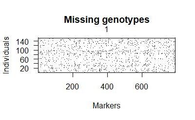

```r
plotMissing(data)
```

Omit the individuals with more than 85% of total markers -> less than 672 markers. Briefly estimate map first.

```r
data<-quickEst(data,map.function="kosambi")
sg<-statGen(data,bychr=F,stat.type="miss",id='index')
data1<-subset(data,ind=om<-sg$miss<(totmar(data))*0.85)
cat(if(F%in%om) which(!om)else "no","ind omitted for missing > 85% mar")
```

```
no ind omitted for missing > 85% mar
```

Plot the number of genotyped markers per individual as well as the number of genotyped individuals per marker

```r
par(mfrow=c(1,2), las=1)
plot(ntyped(data1), ylim=c(0,totmar(data1)+50),ylab="No. typed markers",main="Typed Markers by Individual")
mtext("A",adj=0)
```

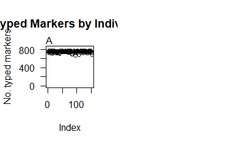

```r
plot(ntyped(data1, "mar"), ylim=c(0,(nind(data1)+15)),ylab="No. typed individuals",main="Typed Individuals by Marker")
mtext("B",adj=0)
```

Plot the genotype frequencies per individual

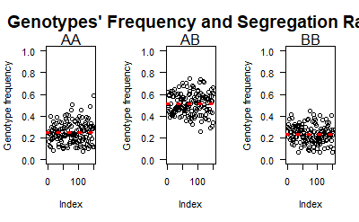

```r
g <- pull.geno(data1)
gfreq <- apply(g, 1, function(a) table(factor(a, levels=1:3)))
gfreq <- t(t(gfreq) / colSums(gfreq))
par(mfrow=c(1,3), las=1)
for(i in 1:3){
  plot(gfreq[i,], ylab="Genotype frequency",ylim=c(0,1))
  abline(h=mean(gfreq[i,]),lty=3,col="red",lwd=3)
  mtext(c("AA", "AB", "BB")[i])}
par(mfrow=c(1,1));title("Genotypes' Frequency and Segregation Ratio",line = 2.5)
```

Compare the genotypes for all pairs of individuals

```r
cg<-comparegeno(data1);cgr<-cg[lower.tri((cg))]
hist(cgr, breaks=seq(0, 1, len=101),xlab="No. matching genotypes", main="Matching Pairs of Individuals")
rug(cgr)
```

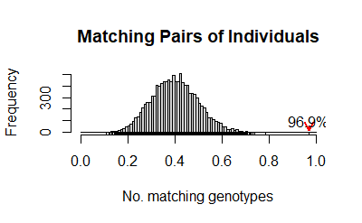

```r
#mark the outlier with a red arrow
x<-max(cgr)
arrow.plot(x,50,0,-1,true.angle = T,arrow.ex=30, length=.1,col='red', lwd=2)
text(x,70,paste0(round(100*x,1),"%"),adj=c(0.5,0.2))
```

Omit individuals with more than 90% identical markers

```r
wh<-which(cg>0.9,arr=T)
data2<-subset(data1,ind=-wh[,2])
cat(nind(data1)-nind(data2),"ind omitted for",paste0(round(100*x,1),"%"),"identical geno\n",paste0("#", data1$pheno$index[wh[,2]]))
```

```
2 ind omitted for 96.9% identical geno
 #132 #134
```

Pull out markers from cross temporarily

```r
cat(totmar(data2),'total mar\n')
```

```
791 total mar
```

```r
data3<-pullCross(data2,type="missing",pars=list(miss.thresh=0.1))
cat(totmar(data3),'total mar\n')
```

```
760 total mar
```

```r
cat(totmar(data2)-totmar(data3),"mar pulled for missing\n")
```

```
31 mar pulled for missing
```

```r
data4<-pullCross(data3,type="seg.distortion",pars=list(seg.thresh=0.001))
cat(totmar(data4),'total mar\n')
```

```
726 total mar
```

```r
cat(totmar(data3)-totmar(data4),"mar pulled for seg. distortion\n")
```

```
34 mar pulled for seg. distortion
```

```r
data5<-pullCross(data4,type="co.located")
cat(totmar(data5),'total mar\n')
```

```
567 total mar
```

```r
cat(totmar(data4)-totmar(data5),"mar pulled for co. located")
```

```
159 mar pulled for co. located
```

Plot optional p. values to determine distance threshold for marker clustering. I chose pValue= 1e-7 (on y axis), meaning->> split linkage groups with more than 30cM gap between markers, according to 150 ind population (on x axis)

```r
cat(nind(data5),"individuals are used to cluster markers")
```

```
150 individuals are used to cluster markers
```

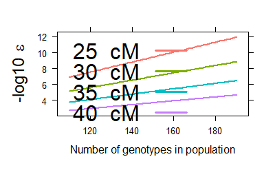

```r
pValue(dist=seq(25,40,by=5),pop.size=110:190)
```

LOD(Logarithm of the Odds)= statistical measure of the likelihood that two loci (positions on a chromosome) are linked and therefore inherited together, rather than assorting independently.

# Map Construction

Form linkage groups with LOD=7, raw map

```r
data5<-mstmap(data5,bychr=F,p.value=1e-7,id='index')
```

```
Number of linkage groups: 28
The size of the linkage groups are: 39  32  47  33  27  12  19  10  38  18  28  19  27  8   11  40  11  13  24  17  16  20  17  1   21  1   16  2
The number of bins in each linkage group: 34    23  35  26  20  9   13  8   30  14  25  15  20  8   10  35  11  11  18  14  14  13  17  1   20  1   12  2
```

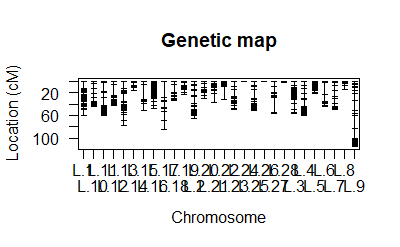

```r
plotMap(data5,alternate.chrid = T)
```

Omit missing/ double crossover (dxo)/ xo statistics outlier individuals

```r
data6<-subsetCross(data5,ind=!pg$xo.lambda)
cat(nind(data5)-nind(data6),"ind omitted by profileGen")
```

```
1 ind omitted by profileGen
```

Double check dxo. An unusually high rate of double crossovers might indicate genotyping errors

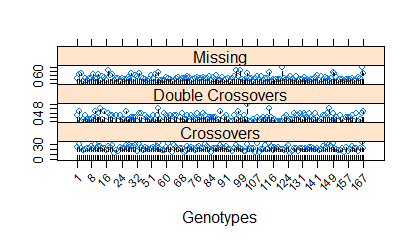

```r
pg1<-profileGen(data6,bychr=F,stat.type=c("xo","dxo","miss"),id="index",xo.lambda=median(pg$stat$xo),layout=c(1,3),lty=2,cex=0.7)
```

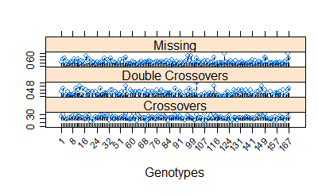

```r
pg1<-profileGen(data6,bychr=F,stat.type=c("xo","dxo","miss"),id="index",xo.lambda=median(pg1$stat$xo),layout=c(1,3),lty=2,cex=0.7)
```

Re-construct map. The genotyping errors can distort the distances between markers, the order of the inputted markers is respected

```r
data7<-mstmap(data6,bychr=F,anchor=T,p.value=1e-7,id='index')
```

```
Number of linkage groups: 28
The size of the linkage groups are: 39  18  28  19  27  8   11  40  11  13  24  32  17  16  20  17  1   21  1   16  2   47  33  27  12  19  10  38
The number of bins in each linkage group: 33    14  25  15  20  8   10  35  11  11  17  22  14  13  13  16  1   20  1   12  2   35  26  19  9   13  8   30
```

Push back markers to the map

```r
cat(totmar(data7),'total mar\n ')
```

```
567 total mar
```

```r
data8<-pushCross(data7,type="co.located")
cat(totmar(data8),'total mar\n ')
```

```
726 total mar
```

```r
cat(totmar(data8)-totmar(data7),"mar pushed for co. located")
```

```
159 mar pushed for co. located
```

Drop LGs with less than 2 markers

```r
mndrop<-markernames(data9,nmar(data9)<2)
data10<-drop.markers(data9,as.character(mndrop))
cat(totmar(data10))
```

```
724
```

```r
cat(totmar(data9)-totmar(data10),"mar omitted for LG < 2 mar")
```

```
2 mar omitted for LG < 2 mar
```

Rename chr by numerical order

```r
x<-1:nchr(data10)
for (i in x) {names(data10$geno)[i]<-paste0("LG",i)}
```

Plot genetic map illustration, final map

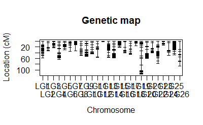

```r
plot.map(data10,alternate.chrid=T)
```

LGs summary table

```r
summaryMap(data10)
```

```
        n.mar length ave.spacing max.spacing
LG1        66   58.5         0.9        12.8
LG2        13   34.4         2.9        14.6
LG3        24   22.3         1.0         4.7
LG4        33   64.0         2.0        11.5
LG5        22   29.9         1.4         6.3
LG6        23   36.1         1.6        15.2
LG7        20   33.8         1.8        21.9
LG8        26   48.9         2.0        11.2
LG9        29   52.6         1.9        17.0
LG10       18   43.9         2.6         8.9
LG11       16   56.6         3.8        25.6
LG12        2    1.9         1.9         1.9
LG13       67   56.7         0.9         9.9
LG14       34   58.7         1.8        10.8
LG15       47   20.8         0.5         4.5
LG16       12   41.1         3.7        18.5
LG17       19   46.6         2.6        10.4
LG18       10   15.7         1.7         8.5
LG19       53  114.3         2.2        23.2
LG20       44   60.7         1.4        14.4
LG21       19   40.9         2.3        19.6
LG22       27   77.1         3.0        14.7
LG23        8   14.9         2.1         4.1
LG24       11   49.3         4.9        26.9
LG25       70   47.8         0.7         6.5
LG26       11   86.3         8.6        28.8
overall   724 1213.7         1.7        28.8
```

# Map Evaluation

Estimate recombination fraction

```r
data10<-est.rf(data10)
```

Heatmap of LOD and Rf

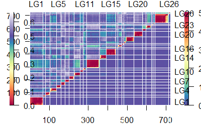

```r
heatMap(data10,lmax = 50,main='')
mtext("Pairwise Recombination Fractions and LOD Scores",cex=1.1,line=3.2,adj=0.4,font=2)
```

Plot Pairwise LOD vs. Rf

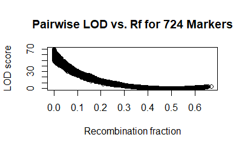

```r
rf<-pull.rf(data10);lod<-pull.rf(data10,what="lod")
plot(as.numeric(rf),as.numeric(lod),xlab="Recombination fraction",ylab="LOD score",main=paste("Pairwise LOD vs. Rf for",totmar(data10),"Markers"))
```

The evaluation looks good:

The heatmap is continuous with low gradient along the chr meaning that the markers within a chromosome are gradually distant from each other.

On the LOD/rf scatter plot there is a trend line with no outliers.

# Exploratory Data Analysis

Jitter map- to avoid marker overlaping by slightly adding gaps between them

```r
data<-jittermap(data10)
```

Create a df of parents phenotype

```r
cold_values <- c(5, 5, 4, 6, 7, 9, 5, 6, 6, 7, NA, NA, 7, 8, 7, 8, 8, 8, 9, 9, 9, 8, NA, NA)
faudpc_values <- c(rep(0, 12), rep(c(90, 142), each = 6))
parents <- data.frame(rbind(matrix(0,12,9), matrix(5,12,9)),faudpc_values, Cold = cold_values,row.names = c(paste0("P1_", 1:12), paste0("DP_", 1:12)))
ant_values <-c(5, 4.5, 4.5, 4.5, 4.5, 3.5, 4, 4.5, 4, 4.5, 4, 4)
parents[13:24,1:3] <-matrix(ant_values,12,3)
colnames(parents) <-phenames(data)[1:11]
head(parents)
```

|  | AFF | AFS | AFL | AG | AYS | AYL | FOB1 | FOB2 | FOB3 | F_AUDPC | Cold |
| --- | --- | --- | --- | --- | --- | --- | --- | --- | --- | --- | --- |
| P1_1 | 0 | 0 | 0 | 0 | 0 | 0 | 0 | 0 | 0 | 0 | 5 |
| P1_2 | 0 | 0 | 0 | 0 | 0 | 0 | 0 | 0 | 0 | 0 | 5 |
| P1_3 | 0 | 0 | 0 | 0 | 0 | 0 | 0 | 0 | 0 | 0 | 4 |
| P1_4 | 0 | 0 | 0 | 0 | 0 | 0 | 0 | 0 | 0 | 0 | 6 |
| P1_5 | 0 | 0 | 0 | 0 | 0 | 0 | 0 | 0 | 0 | 0 | 7 |
| P1_6 | 0 | 0 | 0 | 0 | 0 | 0 | 0 | 0 | 0 | 0 | 9 |

Check the phenotypic distribution

Plot histograms or barplots

```r
cbind(phenames(data))
```

```
      [,1]
 [1,] "AFF"
 [2,] "AFS"
 [3,] "AFL"
 [4,] "AG"
 [5,] "AYS"
 [6,] "AYL"
 [7,] "FOB1"
 [8,] "FOB2"
 [9,] "FOB3"
[10,] "F_AUDPC"
[11,] "Cold"
[12,] "FOB3_bin"
[13,] "BDM"
[14,] "index"
```

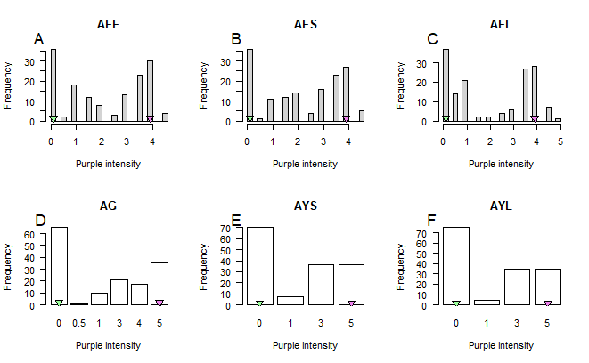

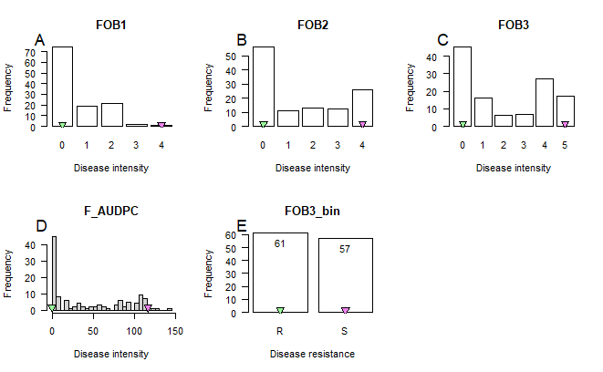

[figure not shown]

```r
par(mfrow = c(2, 3))
l <- 1
for (i in c(1:10, 12, 15, 13, 11)) {
  if (i < 12) {
    plotPheno(data, i, ylab = "Frequency", xlab = if (i < 7) "Purple intensity" else "Disease intensity")}
  if (i == 15) {
    par(mfrow = c(2, 3))}
  if (i > 11 & i != 15) {
    BP <- plotPheno(data, i, ylab = "Frequency",xlab = "Disease resistance",names.arg = c("R", "S"))
    text(BP, table(data$pheno[, i]),labels = table(data$pheno[, i]),pos = 1)
    points(c(0.7, 1.9), rep(1.6, 2), pch = 25,cex = 1.3,bg = c("palegreen1", "violet"))}
   if (i < 10) {
     points(if (i < 4) 0.1 else 0.7, 1.6, pch = 25, cex = 1.3, bg = "palegreen1")}
   if (i < 4) {
     points(mean(parents[13:24, i]) - 0.4, 1.6, pch = 25, cex = 1.3, bg = "violet")}
   if (i == 10) {
    points(c(mean(parents[1:12, i]) - 0.1, mean(parents[13:24, i])), rep(1.6, 2), pch = 25, cex = 1.3, bg = c("palegreen1", "violet"))}
  if (i == 11) {
    points(c(mean(parents[1:12, i], na.rm = TRUE), mean(parents[13:24, i], na.rm = TRUE)), rep(1.6, 2), pch = 25, cex = 1.3, bg = c("palegreen1", "violet"))}
  if (i %in% c(4, 5, 6, 9)) {
    points(if (i == 4) 6.7 else if (i == 9) 6.7 else if (i == 5 || i == 6) 4.3, 1.6, pch = 25, cex = 1.3, bg = "violet")}
   if (i %in% c(7, 8)) {
     points(5.5, 1.6, pch = 25, cex = 1.3, bg = "violet")}
   if (l > 6) l <- 1
   if (i %in% c(1:10, 12)) {
     if (i == 7) l <- 1
     mtext(LETTERS[l], adj = -0.1, cex = 1.1)}
   l <- l + 1
}
```

Plot the correlation matrices using corrplot

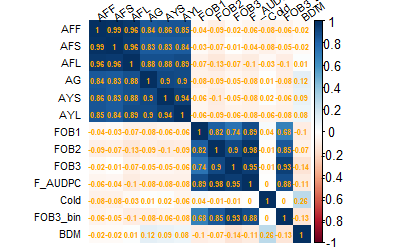

```r
mat<-cor(pull.pheno(data,1:13),use = "complete.obs")
corrplot(mat, method = "color", addCoef.col = "orange", tl.col = "black", tl.srt = 35,tl.cex=0.7,number.cex=0.5)
```

Now, for each group of phenotypes

Fusarium

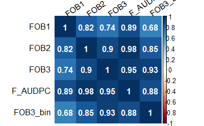

```r
mat<-cor(pull.pheno(data,c(7:10,12)),use = "complete.obs")
corrplot(mat, method = "color", addCoef.col = "white", tl.col = "black", tl.srt = 35)
```

Anthocyanin

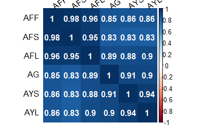

```r
mat<-cor(pull.pheno(data,1:6),use = "complete.obs")
corrplot(mat, method = "color", addCoef.col = "white", tl.col = "black", tl.srt = 35)
```

There is a strong correlation between the phenotypes in the same group. the different conditions (in anthocyanin) or repetitions (in fusarium) had a limited effect on the resulting phenotype.

# QTL Analysis

Perform genome scans to identify QTL

```r
if (all(file.exists("genome_scans.Rdata","scan2_part1.Rdata","scan2_lod_part2.Rdata"))) {
  message("Loading precomputed genome scans from genome_scans.Rdata to save time.")
  load("genome_scans.Rdata")
  # Load the parts (scan2 is a large file so i split it to 2 parts)
  load("scan2_part1.Rdata")
  load("scan2_lod_part2.Rdata")
  lod_part1<-scan2.partial$lod
  # Combine the 'lod' matrix parts back into a single matrix
  combined_lod <- array(NA, dim = c(dim(lod_part1)[1] + dim(lod_part2)[1], dim(lod_part1)[2], dim(lod_part1)[3]))
  # Copy the data from the parts into the combined array
  combined_lod[1:dim(lod_part1)[1], , ] <- lod_part1
  combined_lod[(dim(lod_part1)[1] + 1):dim(combined_lod)[1], , ] <- lod_part2
  # Set the dimnames attribute correctly
  dimnames(combined_lod) <- dimnames(scan2.partial$lod)
  # Reconstruct the scantwo object
  scan2 <- scan2.partial  # Copy the original object structure
  scan2$lod <- combined_lod  # Replace the 'lod' part with the combined matrix
  # cleanup
  rm(list=c("scan2.partial","combined_lod","lod_part1","lod_part2"))
} else {
  cat("The precomputed genome scans were not found\n")
  message("Performing genome scans... This may take a long time.")

  ###ScanOne###
  #calculate probabilities (necessary for scanone)
  #normal #Haley-knott regression
  data<-calc.genoprob(data,2,map.function="kosambi")
  #genome scan for Single-QTL
  scan1<-scanone(data,pheno.col=c(1:n),method="hk")
  #permutation test
  operm <- vector("list", 100)
  for(i in 1:100){operm[[i]]<-scanone(data,pheno.col=c(1:n),method="hk",n.perm=9,n.cluster=2)}
  scan1perm<-do.call("rbind", operm)

  #binary #EM algorithm maximum likelihood
  data<-calc.genoprob(data,3,map.function="kosambi")
  #genome scan for Single-QTL
  scan1.bin<-scanone(data,pheno.col=c(12:13),method="em",model="binary")
  #permutation test
  scan1perm.bin1<-scanone(data,pheno.col=c(12:13),method="em",model="binary",n.perm=1000,n.cluster=2)
  operm <- vector("list", 100)
  for(i in 1:100){operm[[i]]<-scanone(data,pheno.col=c(12:13),method="em",model="binary",n.perm=10,n.cluster=2)}
   scan1perm.bin1<-do.call("rbind", operm)

   save(scan1,scan1.bin,scan1perm,scan1perm.bin,scan2.bin,scan2perm,scan2perm.bin,file="genome_scans.Rdata")

   ###ScanTwo###
   #normal #scan genome for Two-QTL model
   data<-clean(data)
   data<-calc.genoprob(data,2,map.function="kosambi")
   scan2<-scantwo(data,pheno.col=c(1:n),method="hk")
   #permutation test
   ##this proccess is heavy so I've split it into 4 parts and then merged the results. with better CPU performance U can run the following line instead:
   ##scan2perm.bin<-scantwo(data,pheno.col=c(1:n),method="hk",n.perm=1000)
   #res1
   operm2 <- vector("list", 100)
   for(i in 1:100 ){operm2[[i]]<-scantwo(data,pheno.col=c(1:6),method="hk",n.perm=9,n.cluster=2)}
   res1<-do.call("rbind", operm2)
   #res2
   operm2 <-vector("list", 100)
   for(i in 1:100 ){operm2[[i]]<-scantwo(data,pheno.col=c(7:8),method="hk",n.perm=9,n.cluster=2)}
   res2<-do.call("rbind", operm2)
   #res3
   operm2 <- vector("list", 100)
   for(i in 1:100 ){operm2[[i]]<-scantwo(data,pheno.col=c(9:10),method="hk",n.perm=9,n.cluster=2)}
   res3<-do.call("rbind", operm2)
   #res4
   operm2 <- vector("list", 100)
   for(i in 1:100 ){operm2[[i]]<-scantwo(data,pheno.col=11,method="hk",n.perm=9,n.cluster=2)}
   res4<-do.call("rbind", operm2)
   #cbind the 11 phenos
   scan2perm<-res1
   for(i in 1:6){scan2perm[[i]]<-cbind(res1[[i]],res2[[i]],res3[[i]],res4[[i]])}

   #binary #genome scan for two-QTL
   data<-calc.genoprob(data,10,map.function="kosambi")
   scan2.bin<-scantwo(data,pheno.col=c(12,13),method="em",model="binary",verbose=T)
   #permutation test
   ##this proccess is heavy so I've split it into 4 parts and then merged the results. with better CPU performance U can run the following line instead:
  ##scan2perm.bin<-scantwo(data,pheno.col=c(12:13),method="em",model="binary",n.perm=1000)
  operm2 <- vector("list", 200)
  for(i in 1:100 ){operm2[[i]]<-scantwo(data,pheno.col=c(12:13),method="em",model="binary",n.perm=5,n.cluster=2)}
   for(i in 101:200 ){operm2[[i]]<-scantwo(data,pheno.col=c(12:13),method="em", model="binary",n.perm=5,n.cluster=2)}
   scan2perm.bin<-do.call("rbind", operm2[1:200])
}
```

```
Loading precomputed genome scans from genome_scans.Rdata to save time.
```

Setting a QTL detection threshold according to permutation tests. The lower the precentage (5%), the better significance of the QTL.

```r
(thresh1.hk<-summary(scan1perm,alpha=c(0.63,0.1,0.05)))
```

```
LOD thresholds (1000 permutations)
     AFF  AFS  AFL   AG  AYS  AYL FOB1 FOB2 FOB3 F_AUDPC Cold
63% 2.25 2.23 2.25 2.24 2.26 2.24 2.24 2.24 2.24    2.24 2.22
10% 3.31 3.32 3.32 3.36 3.45 3.33 3.32 3.37 3.38    3.35 3.26
5%  3.74 3.68 3.69 3.71 3.77 3.80 3.70 3.77 3.70    3.76 3.62
```

```r
(thresh2.em<-summary(scan1perm.bin,alpha=c(0.63,0.1,0.05)))
```

```
LOD thresholds (1000 permutations)
    FOB3_bin  BDM
63%     2.23 2.25
10%     3.26 3.26
5%      3.71 3.62
```

Scan for additional QTL after reducing the masking effect of QTL with major peaks.

```r
#normal #add additional QTL
qtlist<-summary(scan1,perms=scan1perm,format="tabByCol",alpha=0.63,ci.function="bayesint")
message("Calculating genoprob step= 2 cM")
```

```
Calculating genoprob step= 2 cM
```

```r
data<-calc.genoprob(data,2,map.function="kosambi")
out.aq<-list();rqtl<-list()
for(i in 1:n){
  if(length(qtlist[[i]][,1])>0){
    p<-phenames(data)[i]
    qtlobj<-makeqtl(data,qtlist[[i]][,1],qtlist[[i]][,2],what="prob")
    rqtl[[p]]<-refineqtl(data,p,qtlobj,method="hk")
    out.aq[[p]]<-addqtl(data,qtlist[[i]][,1],p,rqtl[[p]],method="hk",verbose=T)
  }
}
```

[output not shown]

[output cut: 184 more lines]

```
LOD increase overall:  0.031
Scanning chr LG13
pos: 40
Iteration 1
 Q1 pos: 40 -> 15.92518
    LOD increase:  0.242
all pos: 40 -> 15.92518
LOD increase at this iteration:  0.242
Iteration 2
 Q1 pos: 15.92518 -> 15.92518
    LOD increase:  0
all pos: 15.92518 -> 15.92518
LOD increase at this iteration:  0
overall pos: 40 -> 15.92518
LOD increase overall:  0.242
```

```
Scanning chr LG19
pos: 30 40 12
Iteration 1
 Q2 pos: 40 -> 26
    LOD increase:  0.338
 Q3 pos: 12 -> 0
    LOD increase:  0.262
 Q1 pos: 30 -> 12.44735
    LOD increase:  0.141
all pos: 30 40 12 -> 12.44735 26 0
LOD increase at this iteration:  0.742
Iteration 2
 Q1 pos: 12.44735 -> 12.44735
    LOD increase:  0
 Q3 pos: 0 -> 0
    LOD increase:  0
 Q2 pos: 26 -> 12
    LOD increase:  0.034
all pos: 12.44735 26 0 -> 12.44735 12 0
LOD increase at this iteration:  0.034
Iteration 3
 Q2 pos: 12 -> 12
    LOD increase:  0
 Q3 pos: 0 -> 0
    LOD increase:  0
 Q1 pos: 12.44735 -> 3.563067
    LOD increase:  0.049
all pos: 12.44735 12 0 -> 3.563067 12 0
LOD increase at this iteration:  0.049
Iteration 4
 Q1 pos: 3.563067 -> 3.563067
    LOD increase:  0
 Q2 pos: 12 -> 12
    LOD increase:  0
 Q3 pos: 0 -> 0
    LOD increase:  0
all pos: 3.563067 12 0 -> 3.563067 12 0
LOD increase at this iteration:  0
overall pos: 30 40 12 -> 3.563067 12 0
LOD increase overall:  0.825
```

```
Scanning chr LG10
Scanning chr LG19
Scanning chr LG24
pos: 40
Iteration 1
 Q1 pos: 40 -> 15.92518
    LOD increase:  0.387
all pos: 40 -> 15.92518
LOD increase at this iteration:  0.387
Iteration 2
 Q1 pos: 15.92518 -> 15.92518
    LOD increase:  0
all pos: 15.92518 -> 15.92518
LOD increase at this iteration:  0
overall pos: 40 -> 15.92518
LOD increase overall:  0.387
```

```
Scanning chr LG19
```

```r
#binary #add QTL
(qtlist.bin<-summary(scan1.bin,perms=scan1perm.bin,format="tabByCol",alpha=0.63,ci.function="bayesint"))
```

```
FOB3_bin:
```

|  | chr | pos | ci.low | ci.high | lod |
| --- | --- | --- | --- | --- | --- |
| 26868 | LG19 | 39.86291 | 30 | 47.09717 | 4.554812 |
| cLG24.loc9 | LG24 | 9.00000 | 0 | 21.00000 | 2.481463 |

```
BDM:
```

|  | chr | pos | ci.low | ci.high | lod |
| --- | --- | --- | --- | --- | --- |
| 234493 | LG13 | 107.0502 | 6 | 115.44695 | 2.711296 |
| cLG24.loc9 | LG24 | 9.0000 | 0 | 25.99493 | 3.154514 |

```r
data<-calc.genoprob(data,3,map.function="kosambi")
out.aq.bin<-list();rqtl.bin<-list()
for(i in 1:2){
  if(length(qtlist.bin[[i]][,1])>0){
    p<-phenames(data)[i+n]
    qtlobj.bin<-makeqtl(data,qtlist.bin[[i]][,1],qtlist.bin[[i]][,2],what="prob")
    rqtl.bin[[p]]<-refineqtl(data,p,qtlobj.bin,method="hk",model="binary")
    out.aq.bin[[p]]<-addqtl(data,qtlist.bin[[i]][,1],p,rqtl.bin[[p]],maxit=1e+9,tol=0.05,method="hk",model="binary",verbose=T)
    #maxit controls the trade-off between computational resources and the precision of the optimization algorithm. Increasing maxit may improve accuracy but also increases computation time.
  }
}
```

```
pos: 39 9
Iteration 1
 Q1 pos: 39 -> 12
    LOD increase:  0.555
 Q2 pos: 9 -> 0
    LOD increase:  0.34
all pos: 39 9 -> 12 0
LOD increase at this iteration:  0.895
Iteration 2
 Q2 pos: 0 -> 0
    LOD increase:  0
 Q1 pos: 12 -> 12
    LOD increase:  0
all pos: 12 0 -> 12 0
LOD increase at this iteration:  0
overall pos: 39 9 -> 12 0
LOD increase overall:  0.895
```

```
Scanning chr LG19
Scanning chr LG24
pos: 56.70621 9
Iteration 1
 Q1 pos: 56.70621 -> 8.160178
    LOD increase:  1.426
 Q2 pos: 9 -> 38.08046
    LOD increase:  0.81
all pos: 56.70621 9 -> 8.160178 38.08046
LOD increase at this iteration:  2.236
Iteration 2
 Q2 pos: 38.08046 -> 38.08046
    LOD increase:  0
 Q1 pos: 8.160178 -> 8.160178
    LOD increase:  0
all pos: 8.160178 38.08046 -> 8.160178 38.08046
LOD increase at this iteration:  0
overall pos: 56.70621 9 -> 8.160178 38.08046
LOD increase overall:  2.236
Scanning chr LG13
Scanning chr LG24
```

Threshold colors

```r
thcol<-c('blue','green','red')
```

Plot the LOD peaks, from the original scan and from the additional scan

```r
#plot qtl peaks of scanone
plot.sc<-function (x,bin=F,sc=scan1,thresh=thresh1.hk,LETTERs=T,l=1,mf=c(2,2),second=F,first=F){
  if (!second) par(mfrow=mf)
  par(cex.lab=1.5,cex.main=1.5)
  for (i in x) {
    p<-phenames(data)[i];if(bin)p<-phenames(data)[i+n]
    plot(sc,lodcolumn=i,main=p,ylab="LOD",bandcol="gray80",ylim=c(0,max(sc[,2+i])+0.5),alternate.chrid = T)
    abline(h=thresh[,i],lty='dotted',lwd=2,col=thcol)
    for(j in 1:3){
      if(thresh[j,i]/par('usr')[4]<1){
        mtext(rownames(thresh)[j],side=4,font=2,adj=thresh[j,i]/(par('usr')[4]-0.2),col=thcol[j])
      }
    }
    if (LETTERs) mtext(LETTERS[l],adj=0,cex=1.3);l<-l+1;if(l>6)l<-1
  }
  if (first==F) par(mfrow=c(1,1))
}
```

Plot LOD score by phenotype

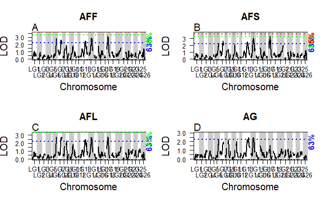

```r
plot.sc(1:6)
```

```r
plot.sc(7:10,first=T)
```

```r
plot.sc(1,T,sc=scan1.bin,thresh=thresh2.em,second=T,l=5)
```

```r
plot.sc(2,T,sc=scan1.bin,thresh=thresh2.em,LETTERs=F,first=T)
plot.sc(11,LETTERs=F,second=T)
```

Customized QTL plotting function, combining original scan and addqtl scan

```r
plotAddqtl<-function(x,bin=F,list=qtlist,aq=out.aq,thresh=thresh1.hk,mfrow=c(2,2),second=F,LETTERs=T,l=1){
  if(!second)par(mfrow=mfrow)
  par(cex.lab=1.5,cex.axis=1.3,cex.main=1.7,cex.sub=1.3)
  for(i in x){
    if(length(list[[i]][,1])>0){
      p<-phenames(data)[i];if(bin)p<-phenames(data)[i+n]
      plot(aq[[p]],alternate.chrid=nrow(list[[p]])>3,ylab="LOD")
      abline(h=thresh[,i],lty='dotted',lwd=2,col=thcol)
      for(j in 1:3){
        if(thresh[j,i]/par('usr')[4]<1){
          mtext(rownames(thresh)[j],cex=0.9,font=2,adj=thresh[j,i]/(par('usr')[4]-0.1),side=4,col=thcol[j])}
      }
      title(p)
      if(nrow(list[[p]])==1)title(sub=list[[p]][,1])
      if (LETTERs) mtext(LETTERS[l],adj=0,cex=1.3);l<-l+1;if(l>6)l<-1
    }
  }
}
```

Plot the QTL, LOD graphs

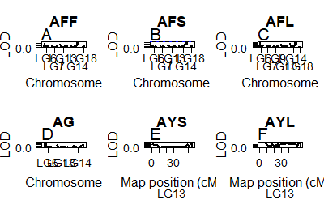

```r
plotAddqtl(1:6,mfrow=c(2,3))
```

```r
plotAddqtl(7:10)
plotAddqtl(1,T,qtlist.bin,out.aq.bin,thresh2.em,second=T,l=4)
```

```r
plotAddqtl(1,T,qtlist.bin,out.aq.bin,thresh2.em,l=6)
```

```r
plotAddqtl(2,T,qtlist.bin,out.aq.bin,thresh2.em,LETTERs=F)
```

Classify the phenotypes for the presence of joint interaction of markers.

```r
intpPhen<-vector();effpPhen<-vector()
for (i in 1:n) {
  (sc1<-summary(scan1,perms=scan1perm,alpha=0.63,lodcolumn=i)[,c(1:2,2+i)])
  p<-phenames(data)[i]
  cat(nrow(sc1),"QTL in",p,"\n")
  if(nrow(sc1)>1) intpPhen<-c(intpPhen,p)
  if(nrow(sc1)==1) effpPhen<-c(effpPhen,p)
  }
```

```
5 QTL in AFF
5 QTL in AFS
6 QTL in AFL
3 QTL in AG
1 QTL in AYS
1 QTL in AYL
0 QTL in FOB1
1 QTL in FOB2
3 QTL in FOB3
1 QTL in F_AUDPC
0 QTL in Cold
```

```r
  #binary
  intpPhen.bin<-vector();effpPhen.bin<-vector()
  for (i in 1:2) {
    (sc1<-summary(scan1.bin,perms=scan1perm.bin,alpha=0.63,lodcolumn=i)[,c(1:2,2+i)])
    p<-phenames(data)[i+n]
    cat(nrow(sc1),"QTL in",p,"\n")
    if(nrow(sc1)>1) intpPhen.bin<-c(intpPhen.bin,p)
    if(nrow(sc1)==1) effpPhen.bin<-c(effpPhen.bin,p)
  }
```

```
2 QTL in FOB3_bin
2 QTL in BDM
```

```r
options(warn=0)
#normal
qtlist<-summary(scan1,perms=scan1perm,format="tabByCol",alpha=0.95,ci.function="bayesint",pvalues=T)
  data<-calc.genoprob(data,2,map.function="kosambi")
  qtlist.aq<-list()
  s.aq<-list()
  for (i in 1:n){
    p<-phenames(data)[i]
    if(!is.null(out.aq[[p]])){
      s<-summary(out.aq[[p]],format="tabByCol",perms=scan1perm[,p],alpha=0.95,ci.function="bayesint",pvalues=T)
      if(nrow(s[[1]])>0){
        qtlist.aq[p]<-s
        qtlist.aq[[p]]<-cbind.data.frame(Trait=p,qtlist.aq[[p]])
        s.aq[[p]]<-summary(out.aq[[p]],perms=scan1perm[,p],alpha=0.63)
        if(nrow(s.aq[[p]])>0){
          rqtl[[p]]<-addtoqtl(data,rqtl[[p]],s.aq[[p]][,1],s.aq[[p]][,2])
        }
      }
    }
  }
  for (i in 1:length(qtlist)){
    if(colnames(qtlist[[i]])[1]!="Trait"){
      qtlist[[i]]<-cbind.data.frame(Trait=names(qtlist[i]),qtlist[[i]])
    }
  }
  qtldf<-do.call(rbind.data.frame,c(qtlist,make.row.names=F))

  for (i in 1:n){
    if(names(qtlist[i])%in%names(qtlist.aq)){
      qtlist[[i]]<-rbind(qtlist[[i]],qtlist.aq[[phenames(data)[i]]])
    }
  }
  qtldf.aq<-do.call(rbind.data.frame,c(qtlist,make.row.names=F))

  #binary
  qtlist<-summary(scan1.bin,perms=scan1perm.bin,format="tabByCol",alpha=0.95,ci.function="bayesint",pvalues=T)
  data<-calc.genoprob(data,3,map.function="kosambi")
  for (i in 1:2){
    p<-phenames(data)[i+n]
    if(!is.null(out.aq.bin[[p]])){
      s<-summary(out.aq.bin[[p]],perms=scan1perm.bin[,p],alpha=0.95,format="tabByCol",ci.function="bayesint",pvalues=T)
      if(nrow(s[[1]])>0){
        qtlist.aq[p]<-s
        qtlist.aq[[p]]<-cbind.data.frame(Trait=p,qtlist.aq[[p]])
        s.aq[[p]]<-summary(out.aq.bin[[p]],perms=scan1perm.bin[,p],alpha=0.63)
        if(nrow(s.aq[[p]])>0){
          rqtl.bin[[p]]<-addtoqtl(data,rqtl.bin[[p]],s.aq[[p]][,1],s.aq[[p]][,2])
        }
      }
    }
  }
  for (i in 1:length(qtlist)){
    qtlist[[i]]<-cbind.data.frame(Trait=names(qtlist[i]),qtlist[[i]])
  }
  for (i in 1:length(qtlist)){
    qtldf<-rbind.data.frame(qtldf,qtlist[[i]],make.row.names=F)
  }
  for (i in 1:2){
    if(names(qtlist[i])%in%names(qtlist.aq)){
      qtlist[[i]]<-rbind(qtlist[[i]],qtlist.aq[[phenames(data)[i+n]]])
    }
  }
  qtldf.aq.bin<-do.call(rbind.data.frame,c(qtlist,make.row.names=F))
  qtldf.aq<-rbind(qtldf.aq,qtldf.aq.bin)
```

```r
su<-1-summary(data)$missing.phe
qtldf.aq<-qtldf.aq%>%
  mutate("Len of LG"=round(chrlen(data)[chr],1),.after=chr)%>%
  mutate("Len of QTL"=round(ci.high-ci.low,1),.after="Len of LG")%>%
  mutate("Flanking markers"=paste0(chr,"_m",find.marker(data,chr,ci.low),"-",chr,"_m",find.marker(data,chr,ci.high)))%>%
  mutate("Central marker"=paste0(chr,"_m",find.marker(data,chr,pos)))%>%
  mutate("Pval"=paste0(pval,if_else(pval<0.63,"*",""),if_else(pval<0.1,"*",""), if_else(pval<0.05,"*","")))%>%
  select(!c(pval,ci.low,ci.high))%>%
  rename("QTL's LG"=chr)%>%
  mutate("No. Inds/% phenotyped"=paste0(nind(data)*su[find.pheno(data,Trait)]," ind / ",round(100*su[find.pheno(data,Trait)],1),"%"),.after=Trait)%>%
  mutate("No. QTLs"="",.before="QTL's LG")%>%
  mutate("pos"=round(pos,1))%>%
  mutate("lod"=round(lod,1))
qtldf.aq
```

| Trait | No. Inds/% phenotyped | No. QTLs | QTL's LG | Len of LG | Len of QTL | pos | lod | Flanking markers | Central marker | Pval |
| --- | --- | --- | --- | --- | --- | --- | --- | --- | --- | --- |
| AFF | 149 ind / 100% |  | LG6 | 36.1 | 29.0 | 56.1 | 2.8 | LG6_m51714-LG6_m34544 | LG6_m34544 | 0.239* |
| AFF | 149 ind / 100% |  | LG7 | 33.8 | 57.2 | 48.0 | 2.6 | LG7_m170952-LG7_m217861 | LG7_m217861 | 0.342* |
| AFF | 149 ind / 100% |  | LG9 | 52.6 | 41.1 | 8.2 | 1.9 | LG9_m148870-LG9_m233623 | LG9_m207796 | 0.849 |
| AFF | 149 ind / 100% |  | LG10 | 43.9 | 32.6 | 45.5 | 1.8 | LG10_m126321-LG10_m254187 | LG10_m254187 | 0.877 |
| AFF | 149 ind / 100% |  | LG13 | 56.7 | 82.0 | 81.3 | 2.5 | LG13_m256334-LG13_m152483 | LG13_m152483 | 0.443* |
| AFF | 149 ind / 100% |  | LG14 | 58.7 | 24.0 | 42.0 | 2.9 | LG14_m180209-LG14_m226669 | LG14_m120084 | 0.219* |
| AFF | 149 ind / 100% |  | LG16 | 41.1 | 77.1 | 0.0 | 1.8 | LG16_m98366-LG16_m1644 | LG16_m98366 | 0.904 |
| AFF | 149 ind / 100% |  | LG18 | 15.7 | 22.0 | 17.6 | 3.1 | LG18_m119483-LG18_m50269 | LG18_m50269 | 0.154* |
| AFF | 149 ind / 100% |  | LG14 | 58.7 | 58.7 | 56.0 | 1.9 | LG14_m187879-LG14_m2633 | LG14_m83713 | 0.863 |
| AFS | 149 ind / 100% |  | LG6 | 36.1 | 44.9 | 56.5 | 2.3 | LG6_m249118-LG6_m34544 | LG6_m34544 | 0.601* |

[output cut: 53 more lines]

Plot marker interactions

```r
data<-sim.geno(data,step=3)
x<-(1:6)[1:6%in%find.pheno(data,intpPhen)]
mergedIntp(x,rit.inx=c(3,6,8,12,15,21,22,26,35))
```

[output not shown]

QTL pairs summary

```r
#normal
c.thr1<-list()
for(i in 1:n){
  (thr1<-summary(scan2, perms=scan2perm, alpha=0.2,lodcolumn=i,pvalues=T))
  if(i==1){c.thr1[[phenames(data)[i]]]<-thr1
  }else c.thr1[[phenames(data)[i]]]<-thr1
}
for (i in 1:length(c.thr1)){
  if(nrow(c.thr1[[i]])>0&&colnames(c.thr1[[i]])[1]!="Trait"){
    c.thr1[[i]]<-cbind.data.frame(Trait=names(c.thr1[i]),c.thr1[[i]])
  }
}
thr1df<-do.call(rbind.data.frame,c(c.thr1,make.row.names=F))
#binary
c.thr2<-list()
for(i in 1:2){
  (thr2<-summary(scan2.bin, perms=scan2perm.bin, alpha=0.2,lodcolumn=i,pvalues=T))
  if(i==1){c.thr2[[phenames(data)[i+n]]]<-thr2
  }else c.thr2[[phenames(data)[i+n]]]<-thr2
}
for (i in 1:length(c.thr2)){
  if(nrow(c.thr2[[i]])>0&&colnames(c.thr2[[i]])[1]!="Trait"){
    c.thr2[[i]]<-cbind.data.frame(Trait=names(c.thr2[i]),c.thr2[[i]])
  }
}
thr2df<-do.call(rbind.data.frame,c(c.thr2,make.row.names=F))
(thr<-rbind(thr1df,thr2df))
```

| Trait | chr1 | chr2 | pos1f | pos2f | lod.full | pval | lod.fv1 | pval | lod.int | pval | pos1a | pos2a | lod.add | pval | lod.av1 | pval |
| --- | --- | --- | --- | --- | --- | --- | --- | --- | --- | --- | --- | --- | --- | --- | --- | --- |
| AFF | LG13 | LG14 | 0 | 14 | 8.006646 | 0.199 | 5.174724 | 0.833 | 2.2286464 | 1 | 0 | 10 | 5.778000 | 0.107 | 2.946077 | 0.098 |
| AFF | LG13 | LG20 | 2 | 22 | 6.968083 | 0.687 | 4.069223 | 1.000 | 1.2145019 | 1 | 0 | 22 | 5.753582 | 0.111 | 2.854722 | 0.125 |
| AFF | LG14 | LG19 | 10 | 34 | 7.041879 | 0.635 | 4.410897 | 1.000 | 1.4670469 | 1 | 10 | 34 | 5.574832 | 0.135 | 2.943851 | 0.098 |
| AFF | LG14 | LG20 | 12 | 18 | 6.791751 | 0.768 | 3.892891 | 1.000 | 1.0876028 | 1 | 12 | 18 | 5.704148 | 0.115 | 2.805288 | 0.141 |
| AFF | LG20 | LG24 | 24 | 32 | 6.522831 | 0.891 | 3.455136 | 1.000 | 0.5409494 | 1 | 24 | 32 | 5.981882 | 0.075 | 2.914187 | 0.109 |
| AFS | LG14 | LG19 | 10 | 34 | 7.448423 | 0.451 | 4.757376 | 0.988 | 1.7672885 | 1 | 12 | 34 | 5.681135 | 0.117 | 2.990088 | 0.090 |
| AFS | LG14 | LG20 | 12 | 18 | 7.087369 | 0.636 | 3.996456 | 1.000 | 0.9732868 | 1 | 12 | 26 | 6.114082 | 0.060 | 3.023169 | 0.087 |
| AFS | LG20 | LG24 | 24 | 32 | 7.137491 | 0.611 | 3.880194 | 1.000 | 0.5974483 | 1 | 24 | 32 | 6.540043 | 0.027 | 3.282745 | 0.034 |
| AFL | LG13 | LG14 | 0 | 14 | 7.956077 | 0.217 | 5.205019 | 0.801 | 2.1826551 | 1 | 0 | 10 | 5.773422 | 0.090 | 3.022364 | 0.067 |
| AFL | LG13 | LG20 | 2 | 22 | 6.894226 | 0.726 | 4.145375 | 1.000 | 1.3144713 | 1 | 0 | 24 | 5.579755 | 0.125 | 2.830903 | 0.126 |

[output cut: 9 more lines]

QTL pairs

```r
#normal
data<-calc.genoprob(data,2,map.function="kosambi")
(qtlist<-summary(scan1,perms=scan1perm,format="tabByCol",alpha=0.63,ci.function="bayesint"))
```

```
AFF:
```

|  | chr | pos | ci.low | ci.high | lod |
| --- | --- | --- | --- | --- | --- |
| 95830 | LG6 | 56.12587 | 27.54780 | 56.52857 | 2.836631 |
| cLG7.loc48 | LG7 | 48.00000 | 1.47694 | 58.63652 | 2.644821 |
| 164757 | LG13 | 81.27314 | 20.00000 | 102.00000 | 2.494735 |
| cLG14.loc42 | LG14 | 42.00000 | 28.00000 | 52.00000 | 2.901180 |
| 115022 | LG18 | 17.61885 | 4.00000 | 26.00000 | 3.089303 |

```
AFS:
```

|  | chr | pos | ci.low | ci.high | lod |
| --- | --- | --- | --- | --- | --- |
| 152483 | LG6 | 56.52857 | 11.655796 | 56.52857 | 2.275622 |
| cLG7.loc48 | LG7 | 48.00000 | 7.048469 | 58.63652 | 2.686425 |
| 164757 | LG13 | 81.27314 | 22.000000 | 103.89531 | 2.497818 |
| cLG14.loc38 | LG14 | 38.00000 | 26.000000 | 52.00000 | 3.069158 |
| 115022 | LG18 | 17.61885 | 4.000000 | 26.00000 | 3.311497 |

```
AFL:
```

|  | chr | pos | ci.low | ci.high | lod |
| --- | --- | --- | --- | --- | --- |
| 95830 | LG6 | 56.125871 | 40 | 56.52857 | 2.775789 |
| cLG7.loc56 | LG7 | 56.000000 | 40 | 58.63652 | 2.761804 |
| 256179 | LG9 | 8.199287 | 0 | 14.00000 | 2.293613 |
| cLG13.loc80 | LG13 | 80.000000 | 26 | 106.24474 | 2.480039 |
| cLG14.loc38 | LG14 | 38.000000 | 26 | 52.00000 | 2.712802 |
| 115022 | LG18 | 17.618853 | 2 | 26.00000 | 2.774921 |

```
AG:
```

|  | chr | pos | ci.low | ci.high | lod |
| --- | --- | --- | --- | --- | --- |
| 95830 | LG6 | 56.12587 | 15.01173 | 56.52857 | 2.265915 |
| 62803 | LG13 | 99.52177 | 66.00000 | 115.44695 | 2.481459 |
| cLG14.loc36 | LG14 | 36.00000 | 28.00000 | 54.00000 | 2.452805 |

```
AYS:
```

|  | chr | pos | ci.low | ci.high | lod |
| --- | --- | --- | --- | --- | --- |
| cLG13.loc76 | LG13 | 76 | 26 | 105.0364 | 2.389012 |

```
AYL:
```

|  | chr | pos | ci.low | ci.high | lod |
| --- | --- | --- | --- | --- | --- |
| cLG13.loc76 | LG13 | 76 | 26 | 115.447 | 2.342281 |

```
FOB2:
```

|  | chr | pos | ci.low | ci.high | lod |
| --- | --- | --- | --- | --- | --- |
| cLG19.loc40 | LG19 | 40 | 8 | 47.83548 | 2.695551 |

```
FOB3:
```

|  | chr | pos | ci.low | ci.high | lod |
| --- | --- | --- | --- | --- | --- |
| 181813 | LG10 | 30.35232 | 24 | 45.52458 | 2.611411 |
| cLG19.loc40 | LG19 | 40.00000 | 16 | 47.83548 | 3.708562 |
| cLG24.loc12 | LG24 | 12.00000 | 0 | 24.00000 | 2.366656 |

```
F_AUDPC:
```

|  | chr | pos | ci.low | ci.high | lod |
| --- | --- | --- | --- | --- | --- |
| cLG19.loc40 | LG19 | 40 | 16 | 47.83548 | 3.150466 |

```r
(sc2thr1<-summary(scan2perm,alpha=0.2))
```

```
pheno 1 (1000 permutations)
    full  fv1  int  add  av1  one
20%    8 6.28 5.65 5.31 2.67 2.93

pheno 2 (1000 permutations)
    full  fv1 int  add  av1  one
20% 8.03 6.28 5.6 5.29 2.73 2.93

pheno 3 (1000 permutations)
    full  fv1  int  add  av1  one
20% 8.01 6.25 5.61 5.29 2.67 2.91

pheno 4 (1000 permutations)
    full fv1  int  add av1  one
20% 8.07 6.3 5.64 5.39 2.7 2.92

pheno 5 (1000 permutations)
    full  fv1  int  add  av1  one
20% 8.07 6.35 5.65 5.32 2.72 2.91

pheno 6 (1000 permutations)
    full  fv1  int  add  av1  one
20% 8.14 6.34 5.66 5.34 2.71 2.92

pheno 7 (1000 permutations)
    full  fv1  int  add  av1  one
20% 9.25 7.57 6.42 5.77 4.12 2.87

pheno 8 (1000 permutations)
    full  fv1  int  add  av1  one
20% 8.39 6.56 5.85 5.41 2.84 2.98

pheno 9 (1000 permutations)
    full  fv1  int  add  av1  one
20% 8.32 6.49 5.77 5.53 2.77 3.04

pheno 10 (1000 permutations)
    full  fv1  int add  av1  one
20% 8.45 6.61 5.82 5.5 2.86 3.07

pheno 11 (1000 permutations)
    full  fv1  int  add  av1  one
20% 8.12 6.42 5.74 5.35 3.03 2.88
```

```r
#rearrange the threshold list
th<-vector('list',5)
for(j in 1:5){th[[j]]<-t(sc2thr1[[j]])}
m<-do.call('cbind',th)
dimnames(m)<-list(phenames(data)[1:n],names(sc2thr1)[1:5])
out.ap<-list();qtlpairs<-list();s.fq<-list();out.fq<-list()
for(i in 1:n){
  p<-phenames(data)[i]
  if(length(qtlist[[p]][,1])>0){
    out.ap[[p]]<-addpair(data,qtlist[[p]][,1],p,rqtl[[p]],method="hk",verbose=T)
    qtlpairs[[p]]<-summary(out.ap[[p]],thresholds=m[p,])
    s.fq[[p]]<-summary(out.fq[[p]]<- fitqtl(data,p,rqtl[[p]],method="hk",get.ests=T))
  }
}
```

[output not shown]

[output cut: 63 more lines]

```
Scanning add've model for chr LG6 and LG6
Scanning full model for chr LG6 and LG13
Scanning add've model for chr LG6 and LG13
Scanning full model for chr LG6 and LG14
Scanning add've model for chr LG6 and LG14
Scanning full model for chr LG13 and LG13
Scanning add've model for chr LG13 and LG13
Scanning full model for chr LG13 and LG14
Scanning add've model for chr LG13 and LG14
Scanning full model for chr LG14 and LG14
Scanning add've model for chr LG14 and LG14
Scanning full model for chr LG13 and LG13
Scanning add've model for chr LG13 and LG13
Scanning full model for chr LG13 and LG13
Scanning add've model for chr LG13 and LG13
```

```
Scanning full model for chr LG19 and LG19
Scanning add've model for chr LG19 and LG19
```

```
Scanning full model for chr LG10 and LG10
Scanning add've model for chr LG10 and LG10
Scanning full model for chr LG10 and LG19
Scanning add've model for chr LG10 and LG19
Scanning full model for chr LG10 and LG24
Scanning add've model for chr LG10 and LG24
Scanning full model for chr LG19 and LG19
Scanning add've model for chr LG19 and LG19
Scanning full model for chr LG19 and LG24
Scanning add've model for chr LG19 and LG24
Scanning full model for chr LG24 and LG24
Scanning add've model for chr LG24 and LG24
```

```
Scanning full model for chr LG19 and LG19
Scanning add've model for chr LG19 and LG19
```

```r
#binary
data<-calc.genoprob(data,10,map.function="kosambi")
(qtlist.bin<-summary(scan1.bin,perms=scan1perm.bin,format="tabByCol",alpha=0.63,ci.function="bayesint"))
```

```
FOB3_bin:
```

|  | chr | pos | ci.low | ci.high | lod |
| --- | --- | --- | --- | --- | --- |
| 26868 | LG19 | 39.86291 | 30 | 47.09717 | 4.554812 |
| cLG24.loc9 | LG24 | 9.00000 | 0 | 21.00000 | 2.481463 |

```
BDM:
```

|  | chr | pos | ci.low | ci.high | lod |
| --- | --- | --- | --- | --- | --- |
| 234493 | LG13 | 107.0502 | 6 | 115.44695 | 2.711296 |
| cLG24.loc9 | LG24 | 9.0000 | 0 | 25.99493 | 3.154514 |

```r
(sc2thr2<-summary(scan2perm.bin,alpha=0.2))
```

```
pheno 1 (1000 permutations)
    full  fv1 int add  av1  one
20% 7.63 6.02 5.5 4.9 2.52 2.67

pheno 2 (1000 permutations)
    full  fv1  int  add  av1  one
20% 7.47 5.88 5.33 4.97 2.47 2.73
```

```r
#rearrange the threshold list
th<-vector('list',5)
for(j in 1:5){th[[j]]<-t(sc2thr2[[j]])}
m.bin<-do.call('cbind',th)
dimnames(m.bin)<-list(phenames(data)[n+1:2],names(sc2thr2)[1:5])
out.ap.bin<-list();rqtl2.bin<-list()
for(i in 1:2){
  p<-phenames(data)[i+n]
  if(length(qtlist.bin[[p]][,1])>0){
    q<-rbind(qtlist.bin[[p]][,-c(3,4)],s.aq[[p]])
    rqtl2.bin[[p]]<-refineqtl(data,p,makeqtl(data,q[,1],q[,2],what="prob"),maxit.fitqtl=1e+6,tol=0.05,method="hk",model="binary")
    out.ap.bin[[p]]<-addpair(data,q[,1],p,rqtl2.bin[[p]],maxit=1e+6,tol=0.2,method="hk",model="binary",verbose=T)
    qtlpairs[[p]]<-summary(out.ap.bin[[p]],thresholds=m.bin[p,])
    s.fq[[p]]<-summary(out.fq[[p]]<- fitqtl(data,p,rqtl2.bin[[p]],maxit=1e+6,tol=0.01,method="hk",model="binary",get.ests=T))
  }
}
```

```
pos: 40 10
Iteration 1
 Q1 pos: 40 -> 11.55165
    LOD increase:  0.518
 Q2 pos: 10 -> 0
    LOD increase:  0.35
all pos: 40 10 -> 11.55165 0
LOD increase at this iteration:  0.867
Iteration 2
 Q2 pos: 0 -> 0
    LOD increase:  0
 Q1 pos: 11.55165 -> 11.55165
    LOD increase:  0
all pos: 11.55165 0 -> 11.55165 0
LOD increase at this iteration:  0
overall pos: 40 10 -> 11.55165 0
LOD increase overall:  0.867
```

```
Scanning full model for chr LG19 and LG19
Scanning add've model for chr LG19 and LG19
Scanning full model for chr LG19 and LG24
Scanning add've model for chr LG19 and LG24
Scanning full model for chr LG24 and LG24
Scanning add've model for chr LG24 and LG24
```

```
pos: 56.70621 10
Iteration 1
 Q2 pos: 10 -> 34.78712
    LOD increase:  0.847
 Q1 pos: 56.70621 -> 8.160178
    LOD increase:  1.324
all pos: 56.70621 10 -> 8.160178 34.78712
LOD increase at this iteration:  2.171
Iteration 2
 Q1 pos: 8.160178 -> 8.160178
    LOD increase:  0
 Q2 pos: 34.78712 -> 38.08046
    LOD increase:  0.069
all pos: 8.160178 34.78712 -> 8.160178 38.08046
LOD increase at this iteration:  0.069
Iteration 3
 Q2 pos: 38.08046 -> 38.08046
    LOD increase:  0
 Q1 pos: 8.160178 -> 8.160178
    LOD increase:  0
all pos: 8.160178 38.08046 -> 8.160178 38.08046
LOD increase at this iteration:  0
overall pos: 56.70621 10 -> 8.160178 38.08046
LOD increase overall:  2.24
Scanning full model for chr LG13 and LG13
Scanning add've model for chr LG13 and LG13
Scanning full model for chr LG13 and LG24
Scanning add've model for chr LG13 and LG24
Scanning full model for chr LG24 and LG24
Scanning add've model for chr LG24 and LG24
```

```r
for (i in 1:length(qtlpairs)){
if(nrow(qtlpairs[[i]])>0 && names(qtlpairs[[i]])[1]!="Trait"){
  qtlpairs[[i]]<-cbind.data.frame(Trait=names(qtlpairs[i]),qtlpairs[[i]])
  }
}
qtlpairsdf<-do.call(rbind.data.frame,c(qtlpairs,make.row.names=F))
#interacting QTL detected for AFL
(qtlpairsdf<-c(qtlpairsdf,thr=m[qtlpairsdf[,1],]))
```

```
$chr1
factor(0)
Levels: LG6 LG7 LG13 LG14 LG18

$chr2
factor(0)
Levels: LG6 LG7 LG13 LG14 LG18

$pos1f
numeric(0)

$pos2f
numeric(0)

$lod.full
numeric(0)

$lod.fv1
numeric(0)

$lod.int
numeric(0)

$pos1a
numeric(0)

$pos2a
numeric(0)

$lod.add
numeric(0)

$lod.av1
numeric(0)
```

No interactive QTL pair was found in the add pair scan.

# Linkage Map view

```r
alp<-0.63
colorlist<-RColorBrewer::brewer.pal(8,"Set1")
```

Genetic map to pdf

```r
qtldf_initial<-\(){
  # make a df to pass qtl info
  qtldf <- data.frame(
    chr = character(),
    qtl = character(),
    so = numeric(),
    si = numeric(),
    ei = numeric(),
    eo = numeric(),
    col = character(),
    stringsAsFactors = F
  )
  return(qtldf)
}
outfile<-file.path("results/basil_linkage_map.pdf")
main<-"Basil Genetic Map"
qtldf<-qtldf_initial()

setting<-list(mapthis=data,outfile=outfile,main=main,ruler=T,maxnbrcolsfordups=2,dupnbr=T,lg.col='lightblue1',lgw=0.15,labdist=0.15,lgperrow=3)
do.call(lmv.linkage.plot,setting)
```

Anthocyanin QTL map

```r
qtldf<-qtldf_initial()
for (i in 1:6) {
  (qtls<-summary(scan1,perms=scan1perm,alpha=alp,lodcolumn=i)[,c(1:2,2+i)])
  if(nrow(qtls)>0){
    for (j in 1:nrow(qtls)) {
      (bay <-bayesint(scan1[,c(1:2,2+i)],chr=qtls$chr[j]))
      qtldf <- rbind(qtldf,
                     data.frame(
                       chr = qtls$chr[j],
                       qtl = colnames(bay)[3],
                       so = bay$pos[1],
                       si = bay$pos[2],
                       ei = bay$pos[2],
                       eo = bay$pos[3],
                       col=colorlist[(i+1)]))
    }
  }
}
outfile<-file.path("results/basil_QTLs.anthocyanin.pdf")
(mapthese<-paste0("LG",sort(unique(as.numeric(qtldf$chr)))))
(main<-paste0("Basil Genetic Map + QTLs for Anthocyanin (",paste0(mapthese,collapse = ","),")"))
setting<-modifyList(setting,list(outfile=outfile,mapthese=mapthese,main=main,qtldf=qtldf))
do.call(lmv.linkage.plot,setting)
```

Fusarium QTL map

```r
qtldf<-qtldf_initial()
for (i in 7:10) {
  qtls<-summary(scan1,perms=scan1perm,alpha=alp,lodcolumn=i)[,c(1:2,2+i)]
  if(nrow(qtls)>0){
    for (j in 1:nrow(qtls)) {
      (bay <-bayesint(scan1[,c(1:2,2+i)],chr=qtls$chr[j]))
      qtldf <- rbind(qtldf,
                     data.frame(
                       chr = qtls$chr[j],
                       qtl = colnames(bay)[3],
                       so = bay$pos[1],
                       si = bay$pos[2],
                       ei = bay$pos[2],
                       eo = bay$pos[3],
                       col=colorlist[(i-5)]))
    }
  }
}
i<-1
(qtls<-summary(scan1.bin,perms=scan1perm.bin,format="tabByCol",alpha=alp,ci.function="bayesint"))
(p<-phenames(data)[i+n])
for (j in 1:(nrow(qtls[[p]])+1)) {
  if(j==3){
    qtls[[p]]<-rbind(qtls[[p]],cbind(s.aq[[p]][,-3],`ci.low`=bayesint(out.aq.bin[[p]],s.aq[[p]][,1])[1,2],`ci.high`=bayesint(out.aq.bin[[p]],s.aq[[p]][,1])[3,2],`lod`=s.aq[[p]][,3]))
  }
  qtldf<-rbind(qtldf,
               data.frame(
                 chr = qtls[[p]]$chr[j],
                 qtl = p,
                 so = qtls[[p]]$`ci.low`[j],
                 si = qtls[[p]]$pos[j],
                 ei = qtls[[p]]$pos[j],
                 eo = qtls[[p]]$`ci.high`[j],
                 col=colorlist[7]))
}
outfile<-file.path("results/basil_QTLs.fusarium.pdf")
(mapthese<-paste0("LG",sort(unique(as.numeric(qtldf$chr)))))
(main<-paste0("Basil Genetic Map + QTLs for Fusarium (",paste0(mapthese,collapse = ","),")"))
setting<-modifyList(setting,list(outfile=outfile,mapthese=mapthese,main=main))
setting$qtldf<-qtldf
do.call(lmv.linkage.plot,setting)
```

Downy Mildew QTL map

```r
qtldf<-qtldf_initial()
i<-2
(qtls<-summary(scan1.bin,perms=scan1perm.bin,format="tabByCol",alpha=alp,ci.function="bayesint"))
p<-phenames(data)[i+n]
for (j in 1:(nrow(qtls[[p]])+1)) {
  if(j==3)qtls[[p]]<-rbind(qtls[[p]],cbind(s.aq[[p]][,-3],`ci.low`=bayesint(out.aq.bin[[p]],s.aq[[p]][,1])[1,2],`ci.high`=bayesint(out.aq.bin[[p]],s.aq[[p]][,1])[3,2],`lod`=s.aq[[p]][,3]))
  qtldf<-rbind(qtldf,
               data.frame(
                 chr = qtls[[p]]$chr[j],
                 qtl = p,
                 so = qtls[[p]]$`ci.low`[j],
                 si = qtls[[p]]$pos[j],
                 ei = qtls[[p]]$pos[j],
                 eo = qtls[[p]]$`ci.high`[j],
                 col=colorlist[8]))
}
outfile<-file.path("results/basil_QTLs.BDM.pdf")
(mapthese<-paste0("LG",sort(unique(as.numeric(qtldf$chr)))))
(main<-paste0("Basil Genetic Map + QTLs for Downy Mildew (",paste0(mapthese,collapse = ","),")"))
setting<-modifyList(setting,list(outfile=outfile,mapthese=mapthese,main=main))
setting$qtldf<-qtldf
do.call(lmv.linkage.plot,setting)
```

The pdf files are in the results folder.

There is more for that project that I have investigated, such as heatmap of scantwo output, multiple qtl model analysis, larger genome-based dataset (5k markers) with the same workflow but takes more computational resources, alignment of the genetic and genomic (large) map side by side anchored by shared markers, comparing the qtl from both maps. I didn’t add it to this notebook because u can see it’s quiet much already.